# Diferencias en las probabilidades de admisión a la educación superior selectiva en Chile según atributos socioeconómicos de los estudiantes

Geraldo Padilla & Lesa Hoffman

23 May, 2023

# Introducción

En Chile, el sistema de educación superior está compuesto por diversas instituciones. Según datos del [Ministerio de Educación](https://educacionsuperior.mineduc.cl/donde-estudiar/), la oferta de estudios superiores del año 2022 estuvo formada por:

- Centros de Formación Técnica (50), que ofrecen formación Técnica de Nivel Superior.
- Institutos Profesionales (32), que ofrecen carreras técnicas y formación profesional, aunque sin grado académico (licenciatura, bachiller o posgrados).
- Universidades (58), que ofrecen carreras técnicas y profesionales con licenciatura, además de opciones de posgrado y postítulo. De las 58, 30 pertenecen al Consejo de Rectores de las Universidades de Chile (CRUCH) y 28 son privadas.

De las 58 universidades registradas en 2022, 45 participaron del Sistema Único de Admisión (SUA), órgano dependiente del CRUCH que ha estado en funcionamiento desde el año 2013 y que determina un mecanismo integrado, simultáneo, objetivo y transparente de admisión a la educación superior selectiva (Barrientos 2019).

Como se puede inferir, el objetivo del SUA es seleccionar candidatos/as, para lo cual se utilizan *factores de selección* cuyos puntajes se han estandarizado en una escala común que va de 150 a 850 puntos. Los más importantes son el NEM (Notas de Enseñanza Media), el Ranking (posición relativa del estudiante en su contexto educativo), y las pruebas obligatorias de admisión que miden los conocimientos en matemáticas y lenguaje.

Durante el proceso de admisión, cada postulante tiene un puntaje para cada factor de admisión. Por su parte, los programas de las universidades participantes del SUA tienen ponderaciones que pueden asignar con relativa autonomía a estos factores. Para cada postulación, el estudiante tiene un puntaje compuesto de postulación (puntaje NEM * ponderación NEM del programa + otros puntajes*otros pesos) que lo posiciona en determinado lugar de la lista de postulantes a ese programa. Según las preferencias del estudiante, puntaje compuesto y vacantes disponibles, será seleccionado/a y podrá matricularse en el programa escogido.

## Características del SUA 2022

- Distintas fechas de rendición (6-7/12, 9-10/12 )
- Priorización curricular debido a la pandemia
- Cambios en las Pruebas de Transición (PDT)

## Admisión: ¿mérito o reproducción de desigualdades?

La segmentación socioeconómica es una realidad transversal en la educación chilena. Si bien diversas evidencias de investigación han reportado diferencias significativas entre estudiantes según sus características territoriales, demográficas y socioeconómicas desde el proceso de admisión hasta el egreso de la educación superior, es difícil aislar estos hallazgos de la forma en que está funcionando el sistema educativo como un todo.

La segmentación socioeconómica y las distintas formas de segregación afectan la trayectoria escolar y formación profesional de varios estudiantes. Por esto, la neutralidad y objetividad del SUA está continuamente en debate. La pregunta sobre si el SUA efectivamente ofrece unas oportunidades comparables a todos/as los y las estudiantes de ingresar a la educación superior selectiva sigue abierta, y los estudios centrados en el impacto o rol de variables socioeconómicas sobre los resultados de admisión son un aporte, cuando menos, al rechazo de estos supuestos.

## Pregunta y objetivo de investigación

De acuerdo a lo mencionado, la pregunta de interés para nuestro estudio es:

¿*Qué efecto tienen los predictores socioeconómicos de interés sobre los distintos resultados de aplicación en el proceso de admisión a la educación superior selectiva del año 2022*?

Por tanto, el objetivo de esta investigación es:

*Estimar/analizar los efectos directos e indirectos de los predictores socioeconómicos de interés sobre los distintos resultados de aplicación en el proceso de admisión a la educación superior selectiva del año 2022 a través de un modelo estadístico multivariante*.

# Metodología

## Diseño

Este es un estudio cuantitativo de diseño transversal, centrado en los resultados del proceso de admisión a la educación superior selectiva del año 2022. Además del análisis descriptivo de los factores académicos de admisión (NEM, Ranking, y pruebas de admisión en matemáticas y lenguaje), se estimó un modelo de senderos, o path analysis, para analizar el efecto que variables socioeconómicas de interés tiene sobre las distintas condiciones o resultados de las postulaciones.

## Datos

Los datos corresponden al proceso de admisión del año 2022, los cuales fueron solicitados al DEMRE a través de su [portal de bases de datos](https://demre.cl/portales/portal-bases-datos). Cabe destacar que a diferencia de procesos anteriores, el DEMRE ahora facilita un único repositorio con la información de las distintas etapas del proceso.

Entre las variables extraídas de la fuente original se encuentran los puntajes en las pruebas de admisión en lenguaje y matemáticas, puntajes derivados de las notas de enseñanza media (NEM y Ranking), educación del padre y la madre, decil de ingresos percápita por familia, y situación de las postulaciones del estudiante.

```r
library(dplyr)

# Database
dat <- readr::read_delim("C:/Users/geral/OneDrive - University of Iowa/PhD portfolio/1.-Research/8. Multivariate analysis of admission progression/2. Database/ADM2022.csv", delim = ";", escape_double = FALSE, trim_ws = TRUE)

# Data cleaning

## Academic filters
dat1 <- dat %>% filter(P166  %in% c('310', '410', '510', '610','710','810','910') & # students who learned from the regular curriculum
                 P015 == 2021 & # students graduated in 2021
                 P083 > 0 & P084 > 0 & P085 > 0 & P086 > 0) # students with valid scores in the academic factors

# Sample
dat2 <- dat1[,c('P034_1', # per capita income
        'P037', # Dad's education
        'P038', # Mom's education
        'P098', # Regular application status
        'P083', # NEM
        'P084', # RKG
        'P085', # LANG
        'P086',# MATH
         'P100',
         'P105',
         'P110',
         'P115',
         'P120',
         'P125',
         'P130',
         'P135',
         'P140',
         'P145')]

dat3 <- dat2 %>% mutate(
  P034_1 = ifelse(P034_1 == 99, NA, P034_1),
  Q_FAM_INC = recode(P034_1,
                     '1' = 1,'2' = 1,
                     '3' = 2,'4' = 2,
                     '5' = 3,'6' = 3,
                     '7' = 4,'8' = 4,
                     '9' = 5,'10' = 5),
  Q2 = ifelse(Q_FAM_INC == 2,1,0),
  Q3 = ifelse(Q_FAM_INC == 3,1,0),
  Q4 = ifelse(Q_FAM_INC == 4,1,0),
  Q5 = ifelse(Q_FAM_INC == 5,1,0),
  P037_1 = ifelse(P037 == 13 | P037 == 99, -1, P037), # father
  P038_1 = ifelse(P038 == 13 | P038 == 99, -1, P038), # mother
  FIRST_G = ifelse(P037_1 > 9 | P038_1 > 9, 0, 1),
  FIRST_G = ifelse(P037_1 == -1 & P038_1 == -1, NA, FIRST_G),
  ADM = ifelse(is.na(P098),0,
               ifelse(P098 == 'C', 1,4)),
  SEL = ifelse(ADM == 4 &
                 (P100 == 24 |
                 P105 == 24 |
                 P110 == 24 |
                 P115 == 24 |
                 P120 == 24 |
                 P125 == 24 |
                 P130 == 24 |
                 P135 == 24 |
                 P140 == 24 |
                 P145 == 24), 1,0),
  SEL2 = ifelse(ADM == 4 & SEL == 1, 1,
               ifelse(ADM == 4 & SEL == 0, 0, NA)),
  ADM2 = ifelse(ADM == 4 & SEL2 == 0,2,
                       ifelse(ADM == 4 & SEL2 == 1,3, ADM)))

# ADM 1 = did not apply;
# 2 = none of his/her applications met the minimum requirements;
# 3 = applied but was not selected;
# 4 = applied and was selected

dat4 <- data.frame(dat3[,c("P083","P084","P085","P086","Q2","Q3","Q4","Q5","FIRST_G","ADM2")])
colnames(dat4) <- c("NEM","RKG","LANG","MATH","Q2","Q3","Q4","Q5","FIRST_G","ADM")
dat4$ADM <- recode(dat4$ADM, '3' = 2, '2' = 3)
dat4 <- dat4 %>% mutate(
  NEM = (NEM - 550)/100,
  RKG = (RKG - 550)/100,
  LANG = (LANG - 550)/100,
  MATH = (MATH - 550)/100)
dat3_5 <- data.frame(dat3[,c(1:8,19:30)])
```

```r
head(dat3_5,10)
```

```
   P034_1 P037 P038 P098 P083 P084 P085 P086 Q_FAM_INC Q2 Q3 Q4 Q5 P037_1 P038_1 FIRST_G ADM SEL SEL2 ADM2
1       7    7   13 <NA>  665  700  346  485         4  0  0  1  0      7     -1       1   0   0   NA    0
2       5   13   11 <NA>  720  783  497  466         3  0  1  0  0     -1     11       0   0   0   NA    0
3       7    9    9 <NA>  560  561  507  551         4  0  0  1  0      9      9       1   0   0   NA    0
4       7   99    5 <NA>  491  492  303  310         4  0  0  1  0     -1      5       1   0   0   NA    0
5       2    5    5    P  807  850  378  622         1  0  0  0  0      5      5       1   4   1    1    3
6      NA   99   99 <NA>  610  630  448  485        NA NA NA NA NA     -1     -1      NA   0   0   NA    0
7       1   13   13    P  742  778  215  355         1  0  0  0  0     -1     -1      NA   4   1    1    3
8      NA   11   10 <NA>  742  797  378  355        NA NA NA NA NA     11     10       0   0   0   NA    0
9       8   10   10 <NA>  593  617  326  456         4  0  0  1  0     10     10       0   0   0   NA    0
10     NA    7    7 <NA>  442  442  311  546        NA NA NA NA NA      7      7       1   0   0   NA    0
```

```r
head(dat4,10)
```

```
     NEM   RKG  LANG  MATH Q2 Q3 Q4 Q5 FIRST_G ADM
1   1.15  1.50 -2.04 -0.65  0  0  1  0       1   0
2   1.70  2.33 -0.53 -0.84  0  1  0  0       0   0
3   0.10  0.11 -0.43  0.01  0  0  1  0       1   0
4  -0.59 -0.58 -2.47 -2.40  0  0  1  0       1   0
5   2.57  3.00 -1.72  0.72  0  0  0  0       1   2
6   0.60  0.80 -1.02 -0.65 NA NA NA NA      NA   0
7   1.92  2.28 -3.35 -1.95  0  0  0  0      NA   2
8   1.92  2.47 -1.72 -1.95 NA NA NA NA       0   0
9   0.43  0.67 -2.24 -0.94  0  0  1  0       0   0
10 -1.08 -1.08 -2.39 -0.04 NA NA NA NA       1   0
```

Como pueden darse cuenta, solo dos variables se consideraron como predictores de interés. En el caso de las variables de caracterización de los colegios, no se agregaron por conveniencia, ya que al incluirlos necesitaríamos ajustar el modelo a la estructura anidada de los datos para identificar adecuamente el rol de cada predictor en distintos niveles (al interior y entre colegios) y no tener errores estándar sesgados en los efectos de nivel 1. Además, como la pregunta de investigación involucra aspectos socioeconómicas, no se agregaron variables demográficas.

## Muestra

Originalmente existen 281.457 registros en la base de datos del proceso de admisión 2022 provista por el DEMRE. Sin embargo, de acuerdo con el objetivo de investigación, se aplicaron 3 filtros a la base de datos original:

1. Egresados/as de enseñanza media técnica o humanista regular (`n = 258.728`)
2. Graduados/as en 2021 (`n = 172.346`)
3. Puntajes válidos en los factores académicos de selección (`n = 150.811`)

Con esto pretendemos definir la unidad de observación: aquel estudiante recién egresado de la educación secundaria, expuesto a los contenidos utilizados para diseñar los exámenes de admisión y que tiene los puntajes necesarios para la construcción del puntaje compuesto para postular a cada programa selectivo.

## Procedimiento

En primer lugar, se realizaron análisis descriptivos de los puntajes en los factores académicos de admisión según las variables de caracterización socioeconómicas escogidas.

Luego, se estimaron dos modelos de senderos en el software Mplus v.8.8, uno con las mediaciones de los factores académicos (estimando los tradicionales efectos `a`, `b` y `c'`), y otro sin estos mediaciones (para obtener regresiones incondicionales). Esto permitiría luego comparar los efectos $c$ (incondicionales) con los $c'$ (condicionales), sin embargo, las formulas disponibles para hacer esto (ver ecuación 11.6 en MacKinnon 2012) consideran solo un mediador, mientras que en nuestro análisis tenemos 4. Por esto, los efectos indirectos se presentan con la clásica opción de a*b (efectos no estandarizados).

El detalle de las variables incluidas en el análisis se encuentra en la Tabla 1. Como es costumbre en los análisis de regresión, y ya que su escala original era muy amplia, los factores académicos fueron centrados en los 550 puntos y luego divididos por 100.

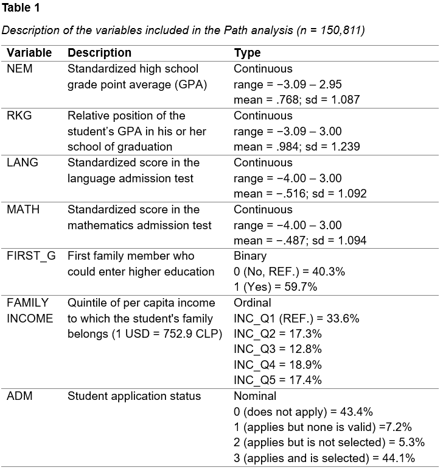

*El análisis de senderos es un modelo de regresión lineal múltiple (o logística multinomial) con esteroides (o buen marketing)*. Es un conjunto de regresiones simultáneas que permite revisar si es que en adición al efecto principal entre el predictor (exógeno o endógeno) y la variable dependiente existen efectos indirectos a través de un mediador que no pueden ser capturado por los modelos de regresión convencionales.

En nuestro caso, los predictores exógenos son las características socioeconómicas FIRST_G y FAMILY_INCOME, con los factores académicos (NEM, RKG, LANG, MATH) actuando como mediadores. Los modelos se estimaron bajo Máxima Verosimilitud con errores estándar robustos (`MLR`), utilizando una distribución condicional `multinomial` para los residuos y la función de enlace logit generalizado (`generalized logit`).

En síntesis, estamos tratando de estimar algo así:

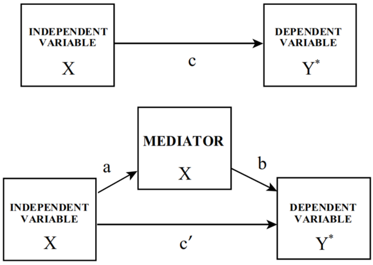

Tomado de MacKinnon (2008,p.303)

Con un modelo que calcula esto:

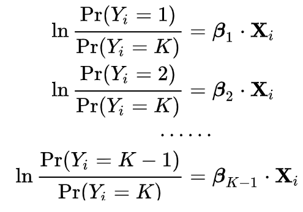

Tomado de https://www.datasklr.com/logistic-regression/multinomial-logistic-regression

Y que luce así:

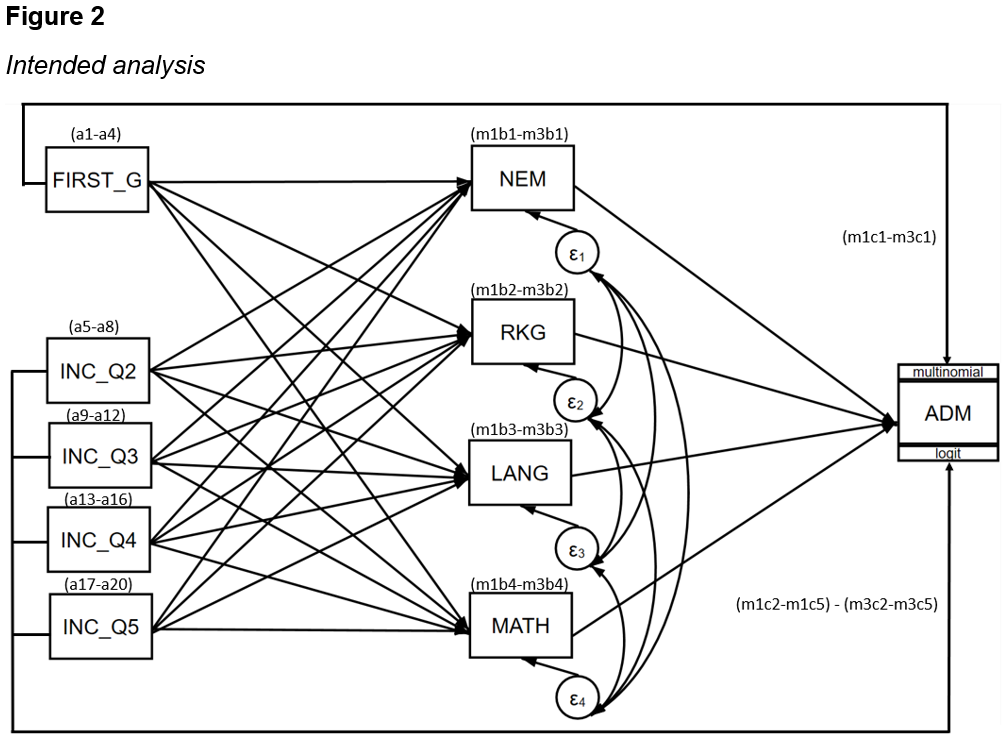

Hecho en SEMBuilder, STATA

El modelo se convertirá en 3 submodelos, cada uno estimando la probabilidad de una categoría K - 1 respecto a K. Por conveniencia, hemos escogido la tercera categoría, postular pero no ser seleccionado/a, como referencia (K).

# Resultados

Como diversas investigaciones han reportado, el nivel de rendimiento en los factores académicos de selección varía entre grupos según variables socioeconómicas.

**Figura 3**

*Rendimiento en los factores de admisión según quintil de ingresos percápita de la familia*

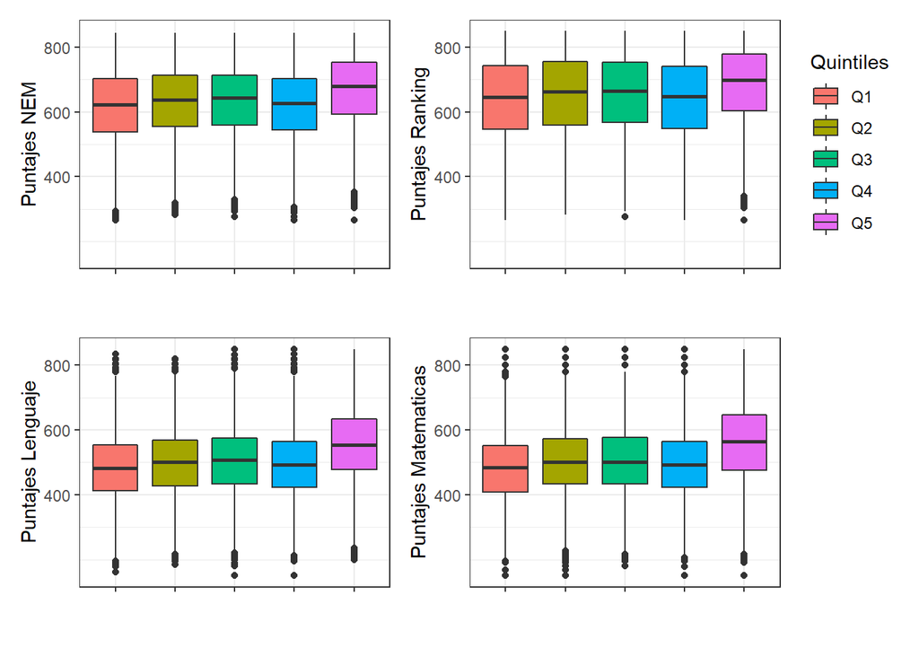

```r
nem_inc <- ggplot(dat5[complete.cases(dat5),], aes(x=FAMILY_INCOME, y = NEM, fill = FAMILY_INCOME))+
  geom_boxplot()+
  labs(y = "Puntajes NEM", x = '')+
  scale_x_discrete(labels = c("", "", "", "", ""))+
  scale_fill_discrete(guide = 'none')+
  scale_y_continuous(limits = c(150, 850), breaks = seq(400, 800, 200)) +
  theme_bw()

rkg_inc <- ggplot(dat5[complete.cases(dat5),], aes(x=FAMILY_INCOME, y = RKG, fill = FAMILY_INCOME))+
  geom_boxplot()+
  labs(y = "Puntajes Ranking", x = '')+
  scale_x_discrete(labels = c("", "", "", "", ""))+
  scale_fill_discrete("Quintiles", labels = c("Q1", "Q2", "Q3", "Q4", "Q5"))+
  scale_y_continuous(limits = c(150, 850), breaks = seq(400, 800, 200)) +
  theme_bw()

lang_inc <- ggplot(dat5[complete.cases(dat5),], aes(x=FAMILY_INCOME, y = LANG, fill = FAMILY_INCOME))+
  geom_boxplot()+
  labs(y = "Puntajes Lenguaje", x = '')+
  scale_x_discrete(labels = c("", "", "", "", ""))+
  scale_fill_discrete(guide = 'none')+
  scale_y_continuous(limits = c(150, 850), breaks = seq(400, 800, 200)) +
  theme_bw()

math_inc <- ggplot(dat5[complete.cases(dat5),], aes(x=FAMILY_INCOME, y = MATH, fill = FAMILY_INCOME))+
  geom_boxplot()+
  labs(y = "Puntajes Matematicas", x = '')+
  scale_x_discrete(labels = c("", "", "", "", ""))+
  scale_fill_discrete(guide = 'none')+
  scale_y_continuous(limits = c(150, 850), breaks = seq(400, 800, 200)) +
  theme_bw()

plot1 <- (nem_inc + rkg_inc)/(lang_inc+math_inc)
plot1
```

**Figura 4**

*Rendimiento en los factores de admisión según educación del padre*

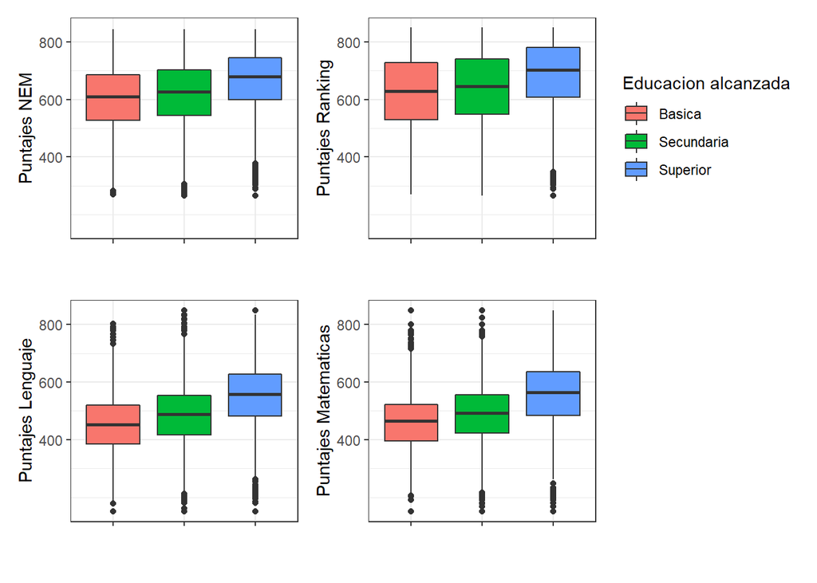

```r
nem_edfather <- ggplot(dat5[complete.cases(dat5),], aes(x=EDUCATION_FATHER, y = NEM, fill = EDUCATION_FATHER))+
  geom_boxplot()+
  labs(y = "Puntajes NEM", x = '')+
  scale_x_discrete(labels = c("", "", ""))+
  scale_fill_discrete(guide = 'none')+
  scale_y_continuous(limits = c(150, 850), breaks = seq(400, 800, 200)) +
  theme_bw()

rkg_edfather <- ggplot(dat5[complete.cases(dat5),], aes(x=EDUCATION_FATHER, y = RKG, fill = EDUCATION_FATHER))+
  geom_boxplot()+
  labs(y = "Puntajes Ranking", x = '')+
  scale_x_discrete(labels = c("", "", ""))+
  scale_fill_discrete("Educacion alcanzada", labels = c("Basica", "Secundaria", "Superior"))+
  scale_y_continuous(limits = c(150, 850), breaks = seq(400, 800, 200)) +
  theme_bw()

lang_edfather <- ggplot(dat5[complete.cases(dat5),], aes(x=EDUCATION_FATHER, y = LANG, fill = EDUCATION_FATHER))+
  geom_boxplot()+
  labs(y = "Puntajes Lenguaje", x = '')+
  scale_x_discrete(labels = c("", "", ""))+
  scale_fill_discrete(guide = 'none')+
  scale_y_continuous(limits = c(150, 850), breaks = seq(400, 800, 200)) +
  theme_bw()

math_edfather <- ggplot(dat5[complete.cases(dat5),], aes(x=EDUCATION_FATHER, y = MATH, fill = EDUCATION_FATHER))+
  geom_boxplot()+
  labs(y = "Puntajes Matematicas", x = '')+
  scale_x_discrete(labels = c("", "", ""))+
  scale_fill_discrete(guide = 'none')+
  scale_y_continuous(limits = c(150, 850), breaks = seq(400, 800, 200)) +
  theme_bw()

plot2 <- (nem_edfather + rkg_edfather)/(lang_edfather+math_edfather)
plot2
```

**Figura 5**

*Rendimiento en los factores de admisión según educación de la madre*

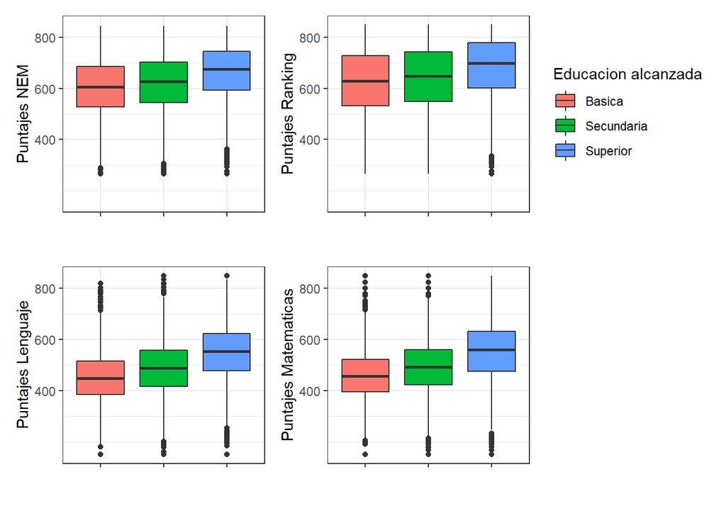

```r
nem_edmother <- ggplot(dat5[complete.cases(dat5),], aes(x=EDUCATION_MOTHER, y = NEM, fill = EDUCATION_MOTHER))+
  geom_boxplot()+
  labs(y = "Puntajes NEM", x = '')+
  scale_x_discrete(labels = c("", "", ""))+
  scale_fill_discrete(guide = 'none')+
  scale_y_continuous(limits = c(150, 850), breaks = seq(400, 800, 200)) +
  theme_bw()

rkg_edmother <- ggplot(dat5[complete.cases(dat5),], aes(x=EDUCATION_MOTHER, y = RKG, fill = EDUCATION_MOTHER))+
  geom_boxplot()+
  labs(y = "Puntajes Ranking", x = '')+
  scale_x_discrete(labels = c("", "", ""))+
  scale_fill_discrete("Educacion alcanzada", labels = c("Basica", "Secundaria", "Superior"))+
  scale_y_continuous(limits = c(150, 850), breaks = seq(400, 800, 200)) +
  theme_bw()

lang_edmother <- ggplot(dat5[complete.cases(dat5),], aes(x=EDUCATION_MOTHER, y = LANG, fill = EDUCATION_MOTHER))+
  geom_boxplot()+
  labs(y = "Puntajes Lenguaje", x = '')+
  scale_x_discrete(labels = c("", "", ""))+
  scale_fill_discrete(guide = 'none')+
  scale_y_continuous(limits = c(150, 850), breaks = seq(400, 800, 200)) +
  theme_bw()

math_edmother <- ggplot(dat5[complete.cases(dat5),], aes(x=EDUCATION_MOTHER, y = MATH, fill = EDUCATION_MOTHER))+
  geom_boxplot()+
  labs(y = "Puntajes Matematicas", x = '')+
  scale_x_discrete(labels = c("", "", ""))+
  scale_fill_discrete(guide = 'none')+
  scale_y_continuous(limits = c(150, 850), breaks = seq(400, 800, 200)) +
  theme_bw()

plot3 <- (nem_edmother + rkg_edmother)/(lang_edmother+math_edmother)
plot3
```

**Figura 6**

*Rendimiento en los factores de admisión según situación de primera generación*

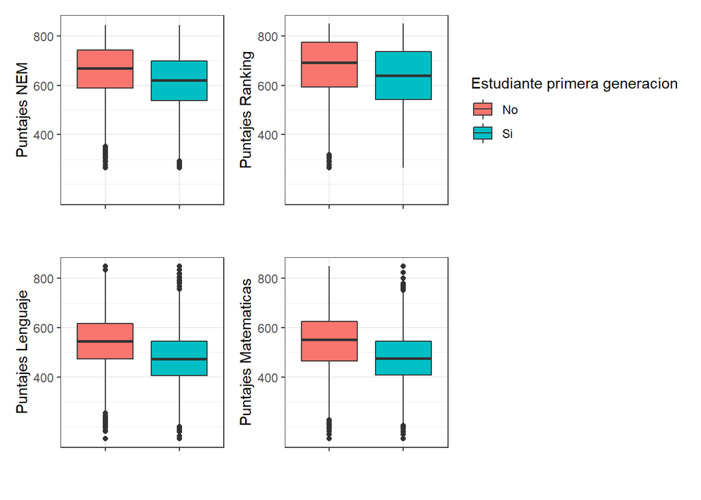

```r
nem_fg <- ggplot(dat5[complete.cases(dat5),], aes(x=FIRST_G, y = NEM, fill = FIRST_G))+
  geom_boxplot()+
  labs(y = "Puntajes NEM", x = '')+
  scale_x_discrete(labels = c("", ""))+
  scale_fill_discrete(guide = 'none')+
  scale_y_continuous(limits = c(150, 850), breaks = seq(400, 800, 200)) +
  theme_bw()

rkg_fg <- ggplot(dat5[complete.cases(dat5),], aes(x=FIRST_G, y = RKG, fill = FIRST_G))+
  geom_boxplot()+
  labs(y = "Puntajes Ranking", x = '')+
  scale_x_discrete(labels = c("", ""))+
  scale_fill_discrete("Estudiante primera generacion", labels = c("No", "Si", "Superior"))+
  scale_y_continuous(limits = c(150, 850), breaks = seq(400, 800, 200)) +
  theme_bw()

lang_fg <- ggplot(dat5[complete.cases(dat5),], aes(x=FIRST_G, y = LANG, fill = FIRST_G))+
  geom_boxplot()+
  labs(y = "Puntajes Lenguaje", x = '')+
  scale_x_discrete(labels = c("", ""))+
  scale_fill_discrete(guide = 'none')+
  scale_y_continuous(limits = c(150, 850), breaks = seq(400, 800, 200)) +
  theme_bw()

math_fg <- ggplot(dat5[complete.cases(dat5),], aes(x=FIRST_G, y = MATH, fill = FIRST_G))+
  geom_boxplot()+
  labs(y = "Puntajes Matematicas", x = '')+
  scale_x_discrete(labels = c("", ""))+
  scale_fill_discrete(guide = 'none')+
  scale_y_continuous(limits = c(150, 850), breaks = seq(400, 800, 200)) +
  theme_bw()

plot4 <- (nem_fg + rkg_fg)/(lang_fg+math_fg)
plot4
```

**Figura 7**

*Rendimiento en los factores de admisión según situación de la postulación*

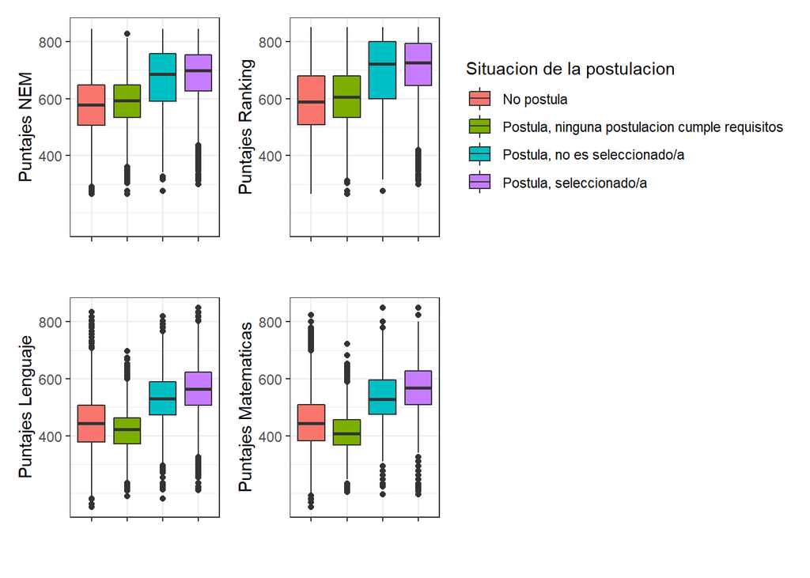

```r
nem_adm <- ggplot(dat5[complete.cases(dat5),], aes(x=ADM, y = NEM, fill = ADM))+
  geom_boxplot()+
  labs(y = "Puntajes NEM", x = '')+
  scale_x_discrete(labels = c("", "", "",''))+
  scale_fill_discrete(guide = 'none')+
  scale_y_continuous(limits = c(150, 850), breaks = seq(400, 800, 200)) +
  theme_bw()

rkg_adm <- ggplot(dat5[complete.cases(dat5),], aes(x=ADM, y = RKG, fill = ADM))+
  geom_boxplot()+
  labs(y = "Puntajes Ranking", x = '')+
  scale_x_discrete(labels = c("", "", "",''))+
  scale_fill_discrete("Situacion de la postulacion", labels = c("No postula",
                                                                "Postula, ninguna postulacion cumple requisitos",
                                                                "Postula, no es seleccionado/a",
                                                                'Postula, seleccionado/a'))+
  scale_y_continuous(limits = c(150, 850), breaks = seq(400, 800, 200)) +
  theme_bw()

lang_adm <- ggplot(dat5[complete.cases(dat5),], aes(x=ADM, y = LANG, fill = ADM))+
  geom_boxplot()+
  labs(y = "Puntajes Lenguaje", x = '')+
  scale_x_discrete(labels = c("", "", "",''))+
  scale_fill_discrete(guide = 'none')+
  scale_y_continuous(limits = c(150, 850), breaks = seq(400, 800, 200)) +
  theme_bw()

math_adm <- ggplot(dat5[complete.cases(dat5),], aes(x=ADM, y = MATH, fill = ADM))+
  geom_boxplot()+
  labs(y = "Puntajes Matematicas", x = '')+
  scale_x_discrete(labels = c("", "", "",''))+
  scale_fill_discrete(guide = 'none')+
  scale_y_continuous(limits = c(150, 850), breaks = seq(400, 800, 200)) +
  theme_bw()

plot5 <- (nem_adm + rkg_adm)/(lang_adm + math_adm)
plot5
```

En general, a medida que las condiciones socioeconómicas mejoran, también lo hacen los puntajes promedio en los factores de admisión. Incluso el Ranking de notas muestra este comportamiento disímil entre grupos de estudiantes.

A continuación, se muestran los resultados de los análisis de senderos. En primer lugar, los efectos de los predictores endógenos y exógenos sobre la probabilidad de admisión en el proceso 2022. En la Tabla 2.1 se muestra un modelo donde la referencia de la variable dependiente es *aplicar pero no ser seleccionado/a*, por lo que cada pendiente corresponde al efecto del predictor sobre el logit de la probabilidad de alguna categoría distinta a **K** respecto a **K**.

Por ejemplo, $ADM#1$ está estimando la probabilidad de **no postular** respecto a **postular y no ser seleccionado/a**. De los factores académicos, se puede observar que los puntajes en lenguaje y matemáticas son especialmente relevantes en la decisión de postular, mientras que a medida que los ingresos económicos percápita de la familia incrementan, se vuelve más probable no postular que postular y arriesgarse a no ser seleccionado/a.

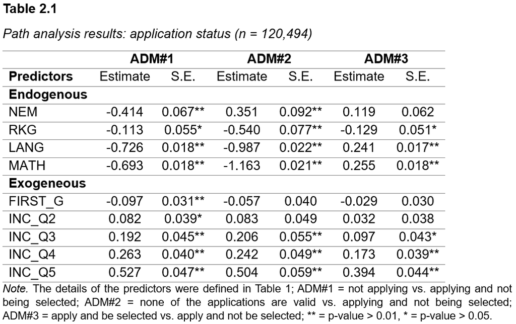

Lo interesante de la Tabla 2.1 es que los efectos de los predictores exógenos (los conocidos efectos `c'`) corresponden a las pendientes de regresión, o comparación entre grupos, ajustadas por los factores académicos. Es decir, que estiman el efecto de los atributos socioeconómicos y la admisión luego de remover el efecto o relación que existe entre los factores académicos y las diferentes resultados de aplicación. Esto es importante, especialmente en ADM#3 y el rol del quintil económico de ingresos, ya que permite identificar mejor el efecto de los predictores sobre la probabilidad de admisión.

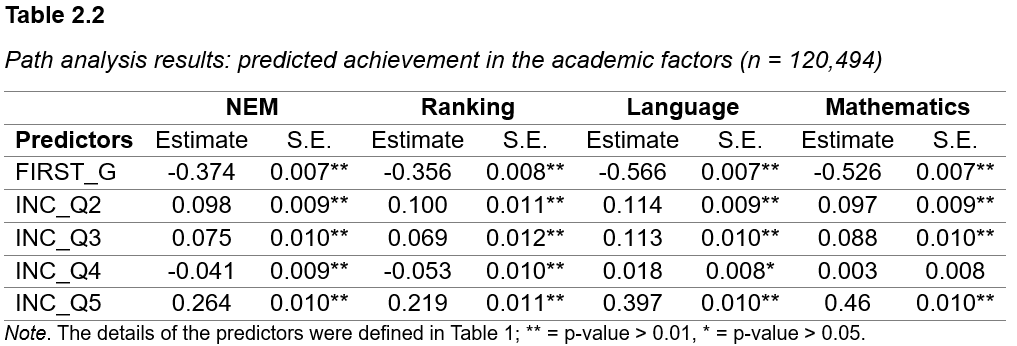

Algo común en los análisis de senderos es la prueba de los efectos indirectos, donde un modelo con variables observadas continuas arroja similares resultados entre las opciones de `c - c'` y `a * b`, sin embargo, debido a que las regresiones `a` son lineales y las `b` logísticas, ambas alternativas no son comparables. Esto ha llevado a una serie de debates metodológicos que no puedo cubrir aquí pero que pueden leer en los trabajos de la carpeta [2. Lecturas recomendadas](https://github.com/Bladimir-PF/PresentacionIESED2023/tree/main/2.%20Lecturas%20recomendadas). Una opción es calcular `c corregido` para luego ser comparados con `c'`, aunque para esto se requiere `b^2`, pero en nuestro caso tenemos 4 effectos b, por lo que esto debe revisarse.

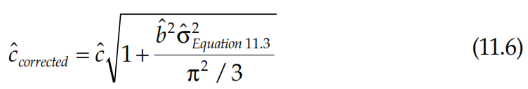

Tomado de MacKinnon (2008,p.307)

Tendiendo esto en consideración, la Tabla 3 muestra los efectos indirectos del modelo (a * b sin estandarizar), la mayoría de los cuales resulta significativo. A diferencia de los resultados anteriores, la interpretación de estos coeficientes no es sencilla, pues tanto los números como su dirección no se pueden interpretar directamente debido a cómo fueron calculadas. Lo que sí podemos decir sobre estos efectos es que muestran el triple rol de las variables socioeconómicas en el proceso de admisión:

1. sobre la situación de las postulaciones aun controlando por los factores académicos (`c'`)
2. sobre los niveles de rendimiento en los factores académicos (`a`)
3. sobre la situación de postulación a través de cada uno de los factores académicos (`a*b`)

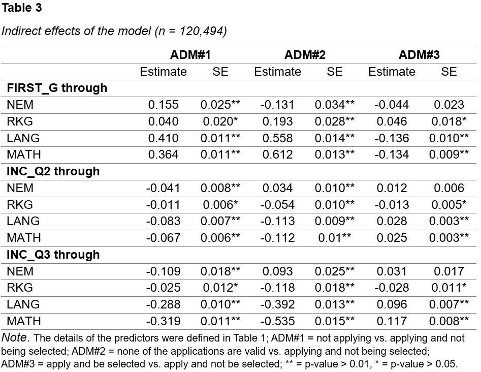

Por último, el modelo también provee los R^2 de los factores académicos, los cuales pese a parecer pequeños, no debemos olvidar que solo consideran dos variables socioeconómicas. Especialmente para el caso de los exámenes de admisión, los predictores exógenos alcanzan a explicar aproximadamente un 10% de su varianza.

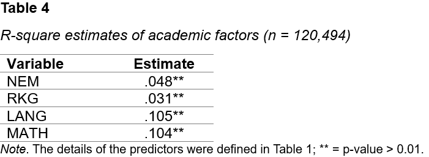

# Conclusiones (preliminares)

- Hay un gran contingente de estudiantes que decide no postular a los programas selectivos, entre los cuales sería importante conocer las razones y si el próximo año participan y cuáles son sus preferencias. Hasta ahora, según los resultados, las probabilidades de no postular incrementan entre los estudiantes de familias de mayores quintiles de ingresos percápita en lugar de postular y no ser seleccionado/a.
- Los factores académicos, en especial los exámenes de admisión, tienen un rol positivo sobre la probabilidad de postular y de admisión.
- Los predictores socioeconómicos fueron significativamente estadísticos en la mayoría de análisis bivariados y multivariantes, incrementando los niveles de rendimiento promedio y las probabilidades de selección cuanto más favorable el nivel de ingresos percápita de la familia y los recursos educativos del padre y/o la madre.

# Cosas por revisar

- cómo corregir los errores estandar de las variables a nivel 2 si es que son agregadas como predictores
- colinearidad con y sin ranking
- khb in stata (Average partial effect) / in r is margins
- estandarizacion del ranking con las tablas del DEMRE
- incluir variables de nivel 2 como grupo de comparacion (grouping = SECTOR)

# Bonus: sitios para aprender a utilizar `R`

Gracias al profesor Ariel Aloe por resumir estos recursos:

- [Rstudio](https://education.rstudio.com/learn/beginner/)
- [R for data science](https://r4ds.had.co.nz)
- [Quick-R](https://www.statmethods.net)
- [W3Schools](https://www.w3schools.com/r/)
- [Guru99](https://www.guru99.com/r-tutorial.html)
- [R UCLA](https://stats.oarc.ucla.edu/r/)

# Referencias

Barrientos, Fernando. 2019. “?‘ Qué Sabemos Sobre Admisión a La Educación Superior? Una Revisión Para Implementación Del Nuevo Sistema de Acceso En Chile.”

MacKinnon, David P. 2012. *Introduction to Statistical Mediation Analysis*. Routledge.